# DS 7374 Project

Muskaan Mahes

## Data Cleaning and Preparation

```r
library(tidyverse)
library(janitor)
library(skimr)
setwd("/Users/muskaanmahes/Downloads/diabetes+130-us+hospitals+for+years+1999-2008")

diabetes.raw = read.csv("diabetic_data.csv") %>%
  clean_names()

#inspecting struture of data
glimpse(diabetes.raw)
```

```
## Rows: 101,766
## Columns: 50
## $ encounter_id             <int> 2278392, 149190, 64410, 500364, 16680, 35754,…
## $ patient_nbr              <int> 8222157, 55629189, 86047875, 82442376, 425192…
## $ race                     <chr> "Caucasian", "Caucasian", "AfricanAmerican", …
## $ gender                   <chr> "Female", "Female", "Female", "Male", "Male",…
## $ age                      <chr> "[0-10)", "[10-20)", "[20-30)", "[30-40)", "[…
## $ weight                   <chr> "?", "?", "?", "?", "?", "?", "?", "?", "?", …
## $ admission_type_id        <int> 6, 1, 1, 1, 1, 2, 3, 1, 2, 3, 1, 2, 1, 1, 3, …
## $ discharge_disposition_id <int> 25, 1, 1, 1, 1, 1, 1, 1, 1, 3, 1, 1, 3, 6, 1,…
## $ admission_source_id      <int> 1, 7, 7, 7, 7, 2, 2, 7, 4, 4, 7, 4, 7, 7, 2, …
## $ time_in_hospital         <int> 1, 3, 2, 2, 1, 3, 4, 5, 13, 12, 9, 7, 7, 10, …
## $ payer_code               <chr> "?", "?", "?", "?", "?", "?", "?", "?", "?", …
## $ medical_specialty        <chr> "Pediatrics-Endocrinology", "?", "?", "?", "?…
## $ num_lab_procedures       <int> 41, 59, 11, 44, 51, 31, 70, 73, 68, 33, 47, 6…
```

[output cut: 37 more lines]

```r
#summary of the data
skim(diabetes.raw)
```

Data summary

| Name | diabetes.raw |
| --- | --- |
| Number of rows | 101766 |
| Number of columns | 50 |
| _______________________ |  |
| Column type frequency: |  |
| character | 37 |
| numeric | 13 |
| ________________________ |  |
| Group variables | None |

**Variable type: character**

| skim_variable | n_missing | complete_rate | min | max | empty | n_unique | whitespace |
| --- | --- | --- | --- | --- | --- | --- | --- |
| race | 0 | 1 | 1 | 15 | 0 | 6 | 0 |
| gender | 0 | 1 | 4 | 15 | 0 | 3 | 0 |
| age | 0 | 1 | 6 | 8 | 0 | 10 | 0 |
| weight | 0 | 1 | 1 | 9 | 0 | 10 | 0 |
| payer_code | 0 | 1 | 1 | 2 | 0 | 18 | 0 |
| medical_specialty | 0 | 1 | 1 | 36 | 0 | 73 | 0 |
| diag_1 | 0 | 1 | 1 | 6 | 0 | 717 | 0 |
| diag_2 | 0 | 1 | 1 | 6 | 0 | 749 | 0 |
| diag_3 | 0 | 1 | 1 | 6 | 0 | 790 | 0 |
| max_glu_serum | 0 | 1 | 4 | 4 | 0 | 4 | 0 |
| a1cresult | 0 | 1 | 2 | 4 | 0 | 4 | 0 |
| metformin | 0 | 1 | 2 | 6 | 0 | 4 | 0 |
| repaglinide | 0 | 1 | 2 | 6 | 0 | 4 | 0 |
| nateglinide | 0 | 1 | 2 | 6 | 0 | 4 | 0 |
| chlorpropamide | 0 | 1 | 2 | 6 | 0 | 4 | 0 |
| glimepiride | 0 | 1 | 2 | 6 | 0 | 4 | 0 |
| acetohexamide | 0 | 1 | 2 | 6 | 0 | 2 | 0 |
| glipizide | 0 | 1 | 2 | 6 | 0 | 4 | 0 |
| glyburide | 0 | 1 | 2 | 6 | 0 | 4 | 0 |
| tolbutamide | 0 | 1 | 2 | 6 | 0 | 2 | 0 |
| pioglitazone | 0 | 1 | 2 | 6 | 0 | 4 | 0 |
| rosiglitazone | 0 | 1 | 2 | 6 | 0 | 4 | 0 |
| acarbose | 0 | 1 | 2 | 6 | 0 | 4 | 0 |
| miglitol | 0 | 1 | 2 | 6 | 0 | 4 | 0 |
| troglitazone | 0 | 1 | 2 | 6 | 0 | 2 | 0 |
| tolazamide | 0 | 1 | 2 | 6 | 0 | 3 | 0 |
| examide | 0 | 1 | 2 | 2 | 0 | 1 | 0 |
| citoglipton | 0 | 1 | 2 | 2 | 0 | 1 | 0 |
| insulin | 0 | 1 | 2 | 6 | 0 | 4 | 0 |
| glyburide_metformin | 0 | 1 | 2 | 6 | 0 | 4 | 0 |
| glipizide_metformin | 0 | 1 | 2 | 6 | 0 | 2 | 0 |
| glimepiride_pioglitazone | 0 | 1 | 2 | 6 | 0 | 2 | 0 |
| metformin_rosiglitazone | 0 | 1 | 2 | 6 | 0 | 2 | 0 |
| metformin_pioglitazone | 0 | 1 | 2 | 6 | 0 | 2 | 0 |
| change | 0 | 1 | 2 | 2 | 0 | 2 | 0 |
| diabetes_med | 0 | 1 | 2 | 3 | 0 | 2 | 0 |
| readmitted | 0 | 1 | 2 | 3 | 0 | 3 | 0 |

**Variable type: numeric**

| skim_variable | n_missing | complete_rate | mean | sd | p0 | p25 | p50 | p75 | p100 | hist |
| --- | --- | --- | --- | --- | --- | --- | --- | --- | --- | --- |
| encounter_id | 0 | 1 | 165201645.62 | 102640295.98 | 12522 | 84961194 | 152388987 | 230270888 | 443867222 | ▆▇▅▂▂ |
| patient_nbr | 0 | 1 | 54330400.69 | 38696359.35 | 135 | 23413221 | 45505143 | 87545950 | 189502619 | ▇▆▆▁▁ |
| admission_type_id | 0 | 1 | 2.02 | 1.45 | 1 | 1 | 1 | 3 | 8 | ▇▂▁▁▁ |
| discharge_disposition_id | 0 | 1 | 3.72 | 5.28 | 1 | 1 | 1 | 4 | 28 | ▇▁▁▁▁ |
| admission_source_id | 0 | 1 | 5.75 | 4.06 | 1 | 1 | 7 | 7 | 25 | ▅▇▁▁▁ |
| time_in_hospital | 0 | 1 | 4.40 | 2.99 | 1 | 2 | 4 | 6 | 14 | ▇▅▂▁▁ |
| num_lab_procedures | 0 | 1 | 43.10 | 19.67 | 1 | 31 | 44 | 57 | 132 | ▃▇▅▁▁ |
| num_procedures | 0 | 1 | 1.34 | 1.71 | 0 | 0 | 1 | 2 | 6 | ▇▂▁▁▁ |
| num_medications | 0 | 1 | 16.02 | 8.13 | 1 | 10 | 15 | 20 | 81 | ▇▃▁▁▁ |
| number_outpatient | 0 | 1 | 0.37 | 1.27 | 0 | 0 | 0 | 0 | 42 | ▇▁▁▁▁ |
| number_emergency | 0 | 1 | 0.20 | 0.93 | 0 | 0 | 0 | 0 | 76 | ▇▁▁▁▁ |
| number_inpatient | 0 | 1 | 0.64 | 1.26 | 0 | 0 | 0 | 1 | 21 | ▇▁▁▁▁ |
| number_diagnoses | 0 | 1 | 7.42 | 1.93 | 1 | 6 | 8 | 9 | 16 | ▁▅▇▁▁ |

```r
#checking
diabetes.raw %>%
  count(readmitted)
```

| readmitted | n |
| --- | --- |
| <30 | 11357 |
| >30 | 35545 |
| NO | 54864 |

```r
#redefine readmitted
diabetes = diabetes.raw %>%
  mutate(
    readmit30 = if_else(readmitted == "<30", 1, 0),
    readmit30 = factor(readmit30, levels =c("No", "Yes"))
  )

head(diabetes)
```

|  | encounter_id | patient_nbr | race | gender | age | weight | admission_type_id | discharge_disposition_id | admission_source_id | time_in_hospital | payer_code | medical_specialty | num_lab_procedures | num_procedures | num_medications | number_outpatient | number_emergency | number_inpatient | diag_1 | diag_2 | diag_3 | number_diagnoses | max_glu_serum | a1cresult | metformin | repaglinide | nateglinide | chlorpropamide | glimepiride | … |
| --- | --- | --- | --- | --- | --- | --- | --- | --- | --- | --- | --- | --- | --- | --- | --- | --- | --- | --- | --- | --- | --- | --- | --- | --- | --- | --- | --- | --- | --- | --- |
| 1 | 2278392 | 8222157 | Caucasian | Female | [0-10) | ? | 6 | 25 | 1 | 1 | ? | Pediatrics-Endocrinology | 41 | 0 | 1 | 0 | 0 | 0 | 250.83 | ? | ? | 1 | None | None | No | No | No | No | No | … |
| 2 | 149190 | 55629189 | Caucasian | Female | [10-20) | ? | 1 | 1 | 7 | 3 | ? | ? | 59 | 0 | 18 | 0 | 0 | 0 | 276 | 250.01 | 255 | 9 | None | None | No | No | No | No | No | … |
| 3 | 64410 | 86047875 | AfricanAmerican | Female | [20-30) | ? | 1 | 1 | 7 | 2 | ? | ? | 11 | 5 | 13 | 2 | 0 | 1 | 648 | 250 | V27 | 6 | None | None | No | No | No | No | No | … |
| 4 | 500364 | 82442376 | Caucasian | Male | [30-40) | ? | 1 | 1 | 7 | 2 | ? | ? | 44 | 1 | 16 | 0 | 0 | 0 | 8 | 250.43 | 403 | 7 | None | None | No | No | No | No | No | … |
| 5 | 16680 | 42519267 | Caucasian | Male | [40-50) | ? | 1 | 1 | 7 | 1 | ? | ? | 51 | 0 | 8 | 0 | 0 | 0 | 197 | 157 | 250 | 5 | None | None | No | No | No | No | No | … |
| 6 | 35754 | 82637451 | Caucasian | Male | [50-60) | ? | 2 | 1 | 2 | 3 | ? | ? | 31 | 6 | 16 | 0 | 0 | 0 | 414 | 411 | 250 | 9 | None | None | No | No | No | No | No | … |

```r
#checking for class balance
diabetes %>%
  count(readmit30) %>%
  mutate(proportions = n /sum(n))
```

| readmit30 | n | proportions |
| --- | --- | --- |
| NA | 101766 | 1 |

```r
#Positive class calucation
x = 11357/101766
x
```

```
## [1] 0.1115992
```

Here I redefined the target variable by classifiying any moments with readmitted == <30 as 30-day readmissions, and the other encounters as not redmitted within 30 days.

< 30 days = 11,357

Only 11% of the encounters are readmitted within 30 days. This is important because the model can predict “No” for almost everyone and it would still look accurate.

```r
#replaces any  missing values with "?"
diabetes = diabetes.raw %>%
  mutate(across(where(is.character), ~na_if(.x, "?"))) %>%
  mutate(
    readmit30 = if_else(readmitted == "<30", 1, 0),
    readmit30 = factor(readmit30, levels = c(0,1), labels = c("No", "Yes"))
  )

#check for missing values
diabetes %>%
  summarise(across(everything(), ~sum(is.na(.x)))) %>%
  pivot_longer(everything(),
               names_to = "variable",
               values_to = "missing_count"
               ) %>%
  arrange(desc(missing_count))
```

| variable | missing_count |
| --- | --- |
| weight | 98569 |
| medical_specialty | 49949 |
| payer_code | 40256 |
| race | 2273 |
| diag_3 | 1423 |
| diag_2 | 358 |
| diag_1 | 21 |
| encounter_id | 0 |
| patient_nbr | 0 |
| gender | 0 |

[output cut: 41 more lines]

```r
diabetes.clean = diabetes.raw %>%
  mutate(across(where(is.character), ~na_if(.x, "?"))) %>%
  mutate(
    readmit30 = if_else(readmitted == "<30", "Yes", "No"),
    readmit30 = factor(readmit30, levels = c("Yes", "No"))
  ) %>%
  dplyr::select(
    -weight,
    -encounter_id, #identifier var
    -patient_nbr, #identifier var
    -readmitted
  ) %>%
  mutate(
    across(where(is.character), ~replace_na(.x, "Uknown")),
    across(where(is.character), as.factor)

  )
```

Decided not to impute the missing values because there is a large count of variables that are missing information. Imputing the variable can add noise/fake certainty. Therefore, missing values were coded as ? were converted to NA. Weight was dropped because it was missing for most of its encounters 98569/101766 which could become less interpretable. Category variables with low/moderaye missing values were kept as “unknown” so that the model can capture the potential information.

```r
glimpse(diabetes.clean)
```

```
## Rows: 101,766
## Columns: 47
## $ race                     <fct> Caucasian, Caucasian, AfricanAmerican, Caucas…
## $ gender                   <fct> Female, Female, Female, Male, Male, Male, Mal…
## $ age                      <fct> [0-10), [10-20), [20-30), [30-40), [40-50), […
## $ admission_type_id        <int> 6, 1, 1, 1, 1, 2, 3, 1, 2, 3, 1, 2, 1, 1, 3, …
## $ discharge_disposition_id <int> 25, 1, 1, 1, 1, 1, 1, 1, 1, 3, 1, 1, 3, 6, 1,…
## $ admission_source_id      <int> 1, 7, 7, 7, 7, 2, 2, 7, 4, 4, 7, 4, 7, 7, 2, …
## $ time_in_hospital         <int> 1, 3, 2, 2, 1, 3, 4, 5, 13, 12, 9, 7, 7, 10, …
## $ payer_code               <fct> Uknown, Uknown, Uknown, Uknown, Uknown, Uknow…
## $ medical_specialty        <fct> Pediatrics-Endocrinology, Uknown, Uknown, Ukn…
## $ num_lab_procedures       <int> 41, 59, 11, 44, 51, 31, 70, 73, 68, 33, 47, 6…
## $ num_procedures           <int> 0, 0, 5, 1, 0, 6, 1, 0, 2, 3, 2, 0, 0, 1, 5, …
## $ num_medications          <int> 1, 18, 13, 16, 8, 16, 21, 12, 28, 18, 17, 11,…
## $ number_outpatient        <int> 0, 0, 2, 0, 0, 0, 0, 0, 0, 0, 0, 0, 0, 0, 0, …
```

[output cut: 34 more lines]

```r
#to check the outcome for inbalace
diabetes.clean %>%
  count(readmit30) %>%
  mutate(proportion = n/sum(n))
```

| readmit30 | n | proportion |
| --- | --- | --- |
| Yes | 11357 | 0.1115992 |
| No | 90409 | 0.8884008 |

```r
#checking fpr unique categories
diabetes.clean %>%
  summarise(across(where(is.factor), n_distinct)) %>%
  pivot_longer(
    everything(),
    names_to = "variable",
    values_to = "n_levels"
  ) %>%
  arrange(desc(n_levels))
```

| variable | n_levels |
| --- | --- |
| diag_3 | 790 |
| diag_2 | 749 |
| diag_1 | 717 |
| medical_specialty | 73 |
| payer_code | 18 |
| age | 10 |
| race | 6 |
| max_glu_serum | 4 |
| a1cresult | 4 |
| metformin | 4 |

[output cut: 26 more lines]

The number of unique categories each variable has was checked. Diagnosis variables like diag_1, diag_2, and diag_3 had many unqiue diagnosis level so we need to group them into a broader category before modeling to improve interpretability.

```r
diagnosis_grouping = function(x){
  x = as.character(x)
  x_num = suppressWarnings(as.numeric(x))

  case_when(
    x == "Unknown" ~ "Unknown",
    str_detect(x, "^[VE]") ~ "External/Supplemnetary",
    x_num >= 250 & x_num < 251 ~ "Diabetes",
    x_num >= 390 & x_num <= 459 ~"Circulatory",
    x_num >= 460 & x_num <= 519 ~"Respiratory",
    x_num >= 520 & x_num <= 579 ~"Digestive",
    x_num >= 580 & x_num <= 629 ~"Geniturinary",
    x_num >= 710 & x_num <= 739 ~"Musculoskeletal",
    x_num >= 800 & x_num <= 999 ~"Injury",
    TRUE~ "Other"
  )
}

#applying to the 3 diagnosis vars
diabetes_model = diabetes.clean %>%
  mutate(
    diagnosis1_group = diagnosis_grouping(diag_1),
    diagnosis2_group = diagnosis_grouping(diag_2),
    diagnosis3_group = diagnosis_grouping(diag_3),
    across(ends_with("_group"), as.factor)
  ) %>%
  dplyr::select(-diag_1, -diag_2, -diag_3) %>%
  mutate(
    readmit30 = factor(readmit30, levels = c("Yes", "No")) #ensuring that readmit is a factor
  )


#checking the factor levels
diabetes_model %>%
  summarise(across(where(is.factor), n_distinct)) %>%
  pivot_longer(
    everything(),
    names_to = "variable",
    values_to = "n_levels"
  ) %>%
  arrange(desc(n_levels))
```

| variable | n_levels |
| --- | --- |
| medical_specialty | 73 |
| payer_code | 18 |
| age | 10 |
| diagnosis1_group | 9 |
| diagnosis2_group | 9 |
| diagnosis3_group | 9 |
| race | 6 |
| max_glu_serum | 4 |
| a1cresult | 4 |
| metformin | 4 |

[output cut: 26 more lines]

```r
#removing the variables with only 1 level
diabetes_model = diabetes_model %>%
  dplyr::select(-examide, -citoglipton)
```

Before grouping diagnosis variable had over 700 level now each group has only 9 level which is much easier to use and explain in a model. Also removed examide and citoglipton because each variable had 1 category and the model cannot learn nor change with just 1 level.

## Model development

```r
library(tidymodels)
diabetes_split = initial_split(
  diabetes_model,
  prop = 0.80,
  strata = readmit30
)

diabetes_train = training(diabetes_split)
diabetes_test = testing(diabetes_split)
```

```r
diabetes_recipe = recipe(readmit30 ~ ., data = diabetes_train) %>%
  step_nzv(all_predictors()) %>%  #removes vars with no variation
  step_other(all_nominal_predictors(), threshold = 0.01) %>% #groups levels that are rare in other
  step_dummy(all_nominal_predictors()) %>%#converts categorical vars into dummy vars
  step_zv(all_predictors())
```

```r
logReg_model = logistic_reg() %>%
  set_engine("glm") %>%
  set_mode("classification")

logReg_wf = workflow() %>%
  add_recipe(diabetes_recipe) %>%
  add_model(logReg_model)

logReg_fit = logReg_wf %>%
  fit(data = diabetes_train)
```

```r
logReg_predictions = predict(logReg_fit, diabetes_test, type = "prob") %>%
  bind_cols(predict(logReg_fit, diabetes_test, type = "class")) %>%
  bind_cols(diabetes_test %>%
              dplyr::select(readmit30))
```

```r
#accuracy & kap
logReg_predictions %>%
  metrics(truth = readmit30,
         estimate = .pred_class)
```

| .metric | .estimator | .estimate |
| --- | --- | --- |
| accuracy | binary | 0.88793358 |
| kap | binary | 0.02309156 |

```r
#ROC
logReg_predictions %>%
  roc_auc(truth = readmit30, .pred_Yes)
```

| .metric | .estimator | .estimate |
| --- | --- | --- |
| roc_auc | binary | 0.6346381 |

```r
#PR_AUC
logReg_predictions %>%
  pr_auc(truth = readmit30, .pred_Yes)
```

| .metric | .estimator | .estimate |
| --- | --- | --- |
| pr_auc | binary | 0.1911555 |

```r
#CM
logReg_predictions %>%
  conf_mat(truth = readmit30, estimate = .pred_class)
```

```
##           Truth
## Prediction   Yes    No
##        Yes    36    45
##        No   2236 18037
```

## tuning threshold to find an optimal option

```r
tuning.threshold = tibble(
  threshold = seq(0.05, 0.50, by = 0.05)
) %>%
  mutate(
    metrics = map(threshold, ~ {
      logReg_predictions %>%
        mutate(
          prediction_threshold = factor(
            if_else(.pred_Yes >= .x, "Yes", "No"),
            levels = c("Yes", "No")
          )

        ) %>%
        summarise(
          true_positives = sum(prediction_threshold == "Yes" & readmit30 == "Yes"),
          false_positives = sum(prediction_threshold == "Yes" & readmit30 == "No"),
          false_negatives = sum(prediction_threshold == "No" & readmit30 == "Yes"),
          true_negatives = sum(prediction_threshold == "No" & readmit30 == "No"),
          recall = true_positives / (true_positives + false_negatives),
          precision = true_positives / (true_positives + false_positives),
          flagged_patients = true_positives + false_positives
        )
    })
  ) %>%
  unnest(metrics)

tuning.threshold
```

| threshold | true_positives | false_positives | false_negatives | true_negatives | recall | precision | flagged_patients |
| --- | --- | --- | --- | --- | --- | --- | --- |
| 0.05 | 2257 | 17622 | 15 | 460 | 0.99339789 | 0.1135369 | 19879 |
| 0.10 | 1445 | 8025 | 827 | 10057 | 0.63600352 | 0.1525871 | 9470 |
| 0.15 | 627 | 2393 | 1645 | 15689 | 0.27596831 | 0.2076159 | 3020 |
| 0.20 | 336 | 921 | 1936 | 17161 | 0.14788732 | 0.2673031 | 1257 |
| 0.25 | 196 | 455 | 2076 | 17627 | 0.08626761 | 0.3010753 | 651 |
| 0.30 | 114 | 241 | 2158 | 17841 | 0.05017606 | 0.3211268 | 355 |
| 0.35 | 86 | 150 | 2186 | 17932 | 0.03785211 | 0.3644068 | 236 |
| 0.40 | 64 | 93 | 2208 | 17989 | 0.02816901 | 0.4076433 | 157 |
| 0.45 | 47 | 61 | 2225 | 18021 | 0.02068662 | 0.4351852 | 108 |
| 0.50 | 36 | 45 | 2236 | 18037 | 0.01584507 | 0.4444444 | 81 |

A threshold of 0.50 is not appropriate for this readmission problem. Lower threshold improved recall but increased the number of patients flagged for intervention –> creates a tradeoff between identifying more high risk patients and managing limited resources. The final threshold should be selected using the model performance and the cost/value assumptions.

## cost and value analysis

```r
#values are under assumptions
cost_per_readmisson = 12000 #readmission cost is $12000
cost_per_intervetion = 200 #post dischae intervention cost is $200/patient
intervention_effectiveness = 0.20 #intervention prevents 20% of readmission among flagged patients

#calculating the net financial
cost.value.Results = tuning.threshold %>%
  mutate(
    expected.readmission.avoided = true_positives * intervention_effectiveness,
    estimated.savings = expected.readmission.avoided * cost_per_readmisson,
    intervention.cost = flagged_patients * cost_per_intervetion,
    net.financial.value = estimated.savings - intervention.cost
  ) %>%
  arrange(desc(net.financial.value))

cost.value.Results
```

| threshold | true_positives | false_positives | false_negatives | true_negatives | recall | precision | flagged_patients | expected.readmission.avoided | estimated.savings | intervention.cost | net.financial.value |
| --- | --- | --- | --- | --- | --- | --- | --- | --- | --- | --- | --- |
| 0.10 | 1445 | 8025 | 827 | 10057 | 0.63600352 | 0.1525871 | 9470 | 289.0 | 3468000 | 1894000 | 1574000 |
| 0.05 | 2257 | 17622 | 15 | 460 | 0.99339789 | 0.1135369 | 19879 | 451.4 | 5416800 | 3975800 | 1441000 |
| 0.15 | 627 | 2393 | 1645 | 15689 | 0.27596831 | 0.2076159 | 3020 | 125.4 | 1504800 | 604000 | 900800 |
| 0.20 | 336 | 921 | 1936 | 17161 | 0.14788732 | 0.2673031 | 1257 | 67.2 | 806400 | 251400 | 555000 |
| 0.25 | 196 | 455 | 2076 | 17627 | 0.08626761 | 0.3010753 | 651 | 39.2 | 470400 | 130200 | 340200 |
| 0.30 | 114 | 241 | 2158 | 17841 | 0.05017606 | 0.3211268 | 355 | 22.8 | 273600 | 71000 | 202600 |
| 0.35 | 86 | 150 | 2186 | 17932 | 0.03785211 | 0.3644068 | 236 | 17.2 | 206400 | 47200 | 159200 |
| 0.40 | 64 | 93 | 2208 | 17989 | 0.02816901 | 0.4076433 | 157 | 12.8 | 153600 | 31400 | 122200 |
| 0.45 | 47 | 61 | 2225 | 18021 | 0.02068662 | 0.4351852 | 108 | 9.4 | 112800 | 21600 | 91200 |
| 0.50 | 36 | 45 | 2236 | 18037 | 0.01584507 | 0.4444444 | 81 | 7.2 | 86400 | 16200 | 70200 |

```r
#identifying the best threshold
cost.value.Results %>%
  slice_max(net.financial.value)
```

| threshold | true_positives | false_positives | false_negatives | true_negatives | recall | precision | flagged_patients | expected.readmission.avoided | estimated.savings | intervention.cost | net.financial.value |
| --- | --- | --- | --- | --- | --- | --- | --- | --- | --- | --- | --- |
| 0.1 | 1445 | 8025 | 827 | 10057 | 0.6360035 | 0.1525871 | 9470 | 289 | 3468000 | 1894000 | 1574000 |

## Threshold and Cost-Value Visualizations

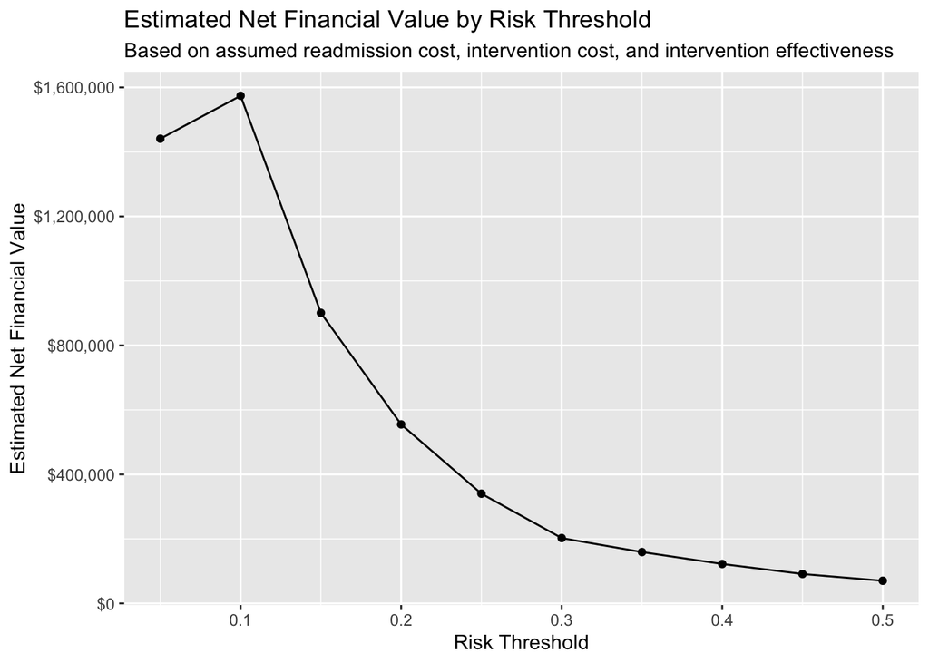

```r
library(scales)
cost.value.Results %>%
  ggplot(aes(x = threshold, y = net.financial.value))+
  geom_line()+
  geom_point()+
  scale_y_continuous(labels = dollar)+
  labs(
    title = "Estimated Net Financial Value by Risk Threshold",
    subtitle = "Based on assumed readmission cost, intervention cost, and intervention effectiveness",
    x = "Risk Threshold",
    y = "Estimated Net Financial Value"

  )
```

The plot shows at a threshold of 0.1 (as we saw previously) creates the highest estimated business value at $1.6 million.

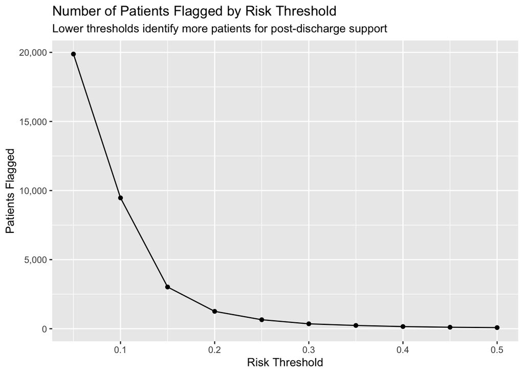

```r
cost.value.Results %>%
  ggplot(aes(x= threshold, y = flagged_patients))+
  geom_line()+
  geom_point()+
  scale_y_continuous(labels = comma)+
  labs(
    title = "Number of Patients Flagged by Risk Threshold",
    subtitle = "Lower thresholds identify more patients for post-discharge support",
    x= "Risk Threshold",
    y = "Patients Flagged"
  )
```

At 0.1 threshold around 10,000 patients were flagged for care-management support.

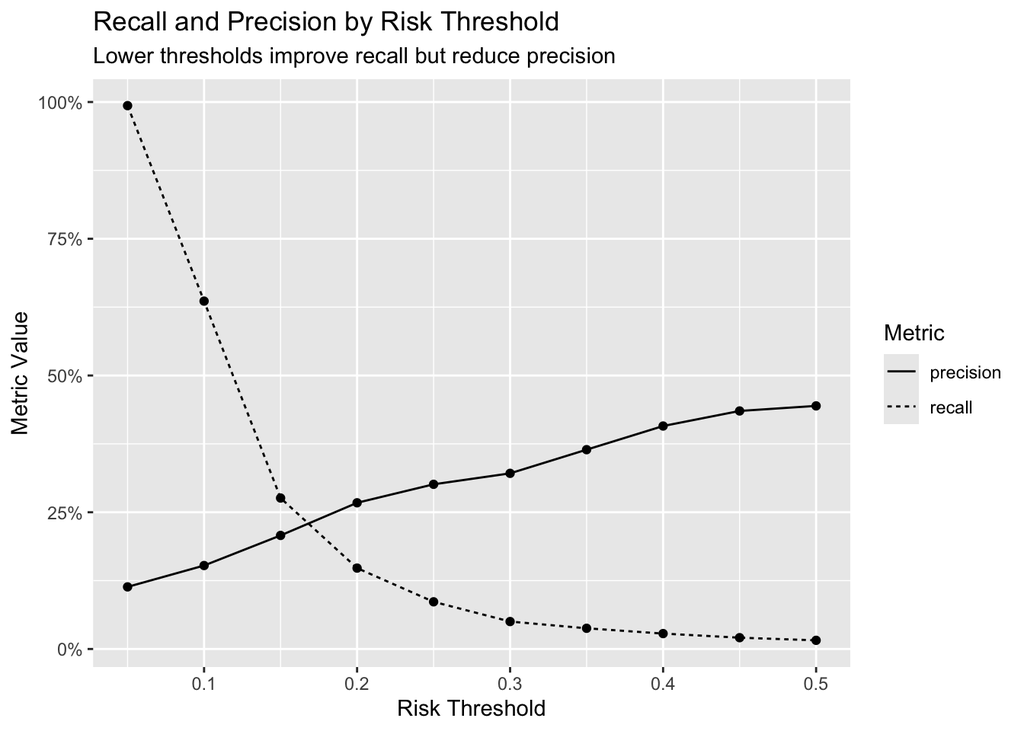

```r
cost.value.Results %>%
  dplyr::select(threshold, recall, precision) %>%
  pivot_longer(
    cols = c(recall, precision),
    names_to = "metric",
    values_to = "value"
  ) %>%
  ggplot(aes(x= threshold, y = value, linetype = metric))+
  geom_line()+
  geom_point()+
  scale_y_continuous(labels = percent)+
  labs(
    title = "Recall and Precision by Risk Threshold",
    subtitle = "Lower thresholds improve recall but reduce precision",
    x = "Risk Threshold",
    y = "Metric Value",
    linetype = "Metric"
  )
```

The plot shows there is a tradeoff between having more readmission and avoiding unnecessary interventions

Chart interpretation: The threshold visualizations show that model performance has to be interpreted as a business tradeoff. Lower risk threshold identify more patients and improve recall, but it also increases the number of patients requiring intervention. At a higher threshold shows reduced care management workload and improve precision, but it misses more true 30-day redamissions. The net financial value chart combines these tradeoffs by estimating the expected savings from avoided readmission minus the cost of interventions. Therefore, a 0.10 threshold produced the highest estimated net financial valye, but the preferred threshold may change if intervention costs, staffing capacity, readmission cost, or intervention effectiveness change.